# digitalLDSorteR: R package for deconvolution of bulk RNA-seq samples based on Deep Learning

## 4.4 Generate cell composition matrix for bulk simulated expression profiles

For simulating bulk samples, first, it is necessary the generation of a cell composition matrix which determines the proportion of each cell type in each sample. It is carried out by `generateTrainAndTestBulkProbMatrix` function and the results are stored in `prob.cell.types` slot as a `ProbMatrixCellTypes` object.

```r
probMatrix <- data.frame(
  Cell_type = c("ER+", "HER2+", "ER+ and HER2+", "TNBC",
                 "Stromal", "Monocyte", "Tme", "BGC",
                 "Bmem", "DC", "Macrophage", "TCD8", "Treg"),
  from = c(rep(30, 4), 1, rep(0, 8)),
  to = c(rep(70, 4), 50, rep(15, 8))
)

DDLSChungSmall <- generateTrainAndTestBulkProbMatrix(
  object = DDLSChungSmall,
  cell.type.column = "Cell_type",
  prob.design = probMatrix,
  num.bulk.samples = 200,
  verbose = TRUE
)
##
## === The number of bulk samples that will be generated has been fixed to 200
##
## === Train Set cells by type:
##     - BGC: 9
##     - Bmem: 10
##     - DC: 5
##     - ER+: 6
##     - ER+ and HER2+: 8
##     - HER2+: 10
##     - Macrophage: 8
##     - Monocyte: 6
##     - Stromal: 7
##     - TCD8: 9
##     - Tme: 9
##     - TNBC: 8
##     - Treg: 6
## === Test Set cells by type:
##     - BGC: 2
##     - Bmem: 2
##     - DC: 6
##     - ER+: 5
##     - ER+ and HER2+: 4
##     - HER2+: 5
##     - Macrophage: 3
##     - Monocyte: 5
##     - Stromal: 4
##     - TCD8: 2
##     - Tme: 3
##     - TNBC: 5
##     - Treg: 5
## === Probability matrix for training data:
##     - Bulk samples: 129
##     - Cell types: 13
## === Probability matrix for test data:
##     - Bulk samples: 71
##     - Cell types: 13
## DONE
```

In this example, we are simulating the proportions of 200 bulk samples for avoid an excessive use of RAM in the following steps. In real circumstances, we recommend, depending on the number of starting single-cell profiles and the available computational resources, about 30000 samples and the default proportions.

You can investigate the cell composition matrix created in this step:

```r
head(getProbMatrix(DDLSChungSmall, type.data = "train"))
##        ER+ HER2+ ER+ and HER2+ TNBC Stromal Monocyte Tme BGC Bmem DC
## Bulk_1  18    16            27   14      11        2   1   3    1  1
## Bulk_2  15    23            23   14      14        1   1   5    1  0
## Bulk_3  19    17            17   19      11        1   3   5    2  4
## Bulk_4  14    19            16   23       6        2   2   6    2  5
## Bulk_5  15    15            24   21       5        0   5   3    0  4
## Bulk_6  24    18            21   14       6        1   4   3    0  0
##        Macrophage TCD8 Treg
## Bulk_1          1    0    5
## Bulk_2          1    2    0
## Bulk_3          0    1    1
## Bulk_4          3    1    1
## Bulk_5          5    2    1
## Bulk_6          4    5    0
tail(getProbMatrix(DDLSChungSmall, type.data = "train"))
##          ER+ HER2+ ER+ and HER2+ TNBC Stromal Monocyte Tme BGC Bmem
## Bulk_124  15     6             1   10       8        5   4   7    7
## Bulk_125  11    12             8    3       4        4   9  11    9
## Bulk_126  14    13             3    5       3        3   7  18   16
## Bulk_127   0     1             0   18      10       16   4   1    6
## Bulk_128   1     8             8   38       3        1  12   4    2
## Bulk_129   2     2             3   14      13       17   4   8    4
##          DC Macrophage TCD8 Treg
## Bulk_124  2          9   11   15
## Bulk_125 13          4    8    4
## Bulk_126  4          3    7    4
## Bulk_127  8          4   28    4
## Bulk_128  3         19    1    0
## Bulk_129  6          4    9   14
```

However, it is more suitable to know full distribution of proportions generated by each method using `showProbPlot` function. This function show different ways for visualizing this information. In the following code, we are going to display the former and the last distributions of train samples:

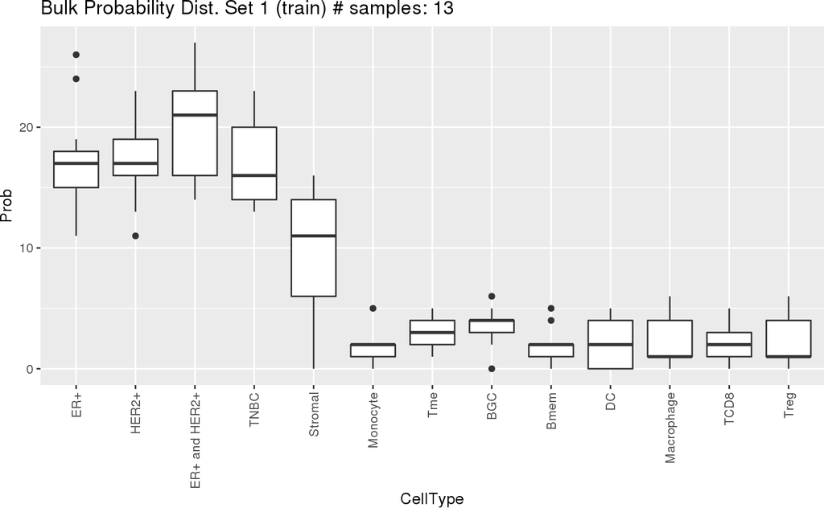

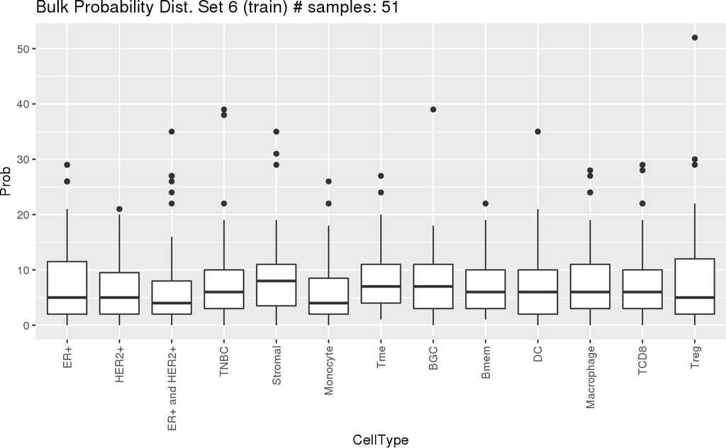

```r
lapply(c(1, 6), function(x) {
  showProbPlot(DDLSChungSmall,
               type.data = "train", set = x, type.plot = "boxplot")
})
## [[1]]
```

Probably, distributions presents different medians between cell types or similar things. This is because of the low number of samples that are being simulated.

## 4.5 Simulate bulk RNA-seq profiles with known cell composition

$$\begin{equation}
T_{ij} = \sum_{k = 1}^{K} \sum_{z = 1}^Z C_{izk}
\tag{1}
\end{equation}$$

$$\begin{equation*}
\textrm{such as} \left\{
\begin{array}{l}
i = 1 \ldots M;\\
j = 1 \ldots N \\
Z = 1 \ldots 100 \cdot P_{kj} \\
\sum_{k = 1}^K Z \cdot P_{kj} = 100
\end{array}
\right.
\end{equation*}$$

where $T_{ij}$ is the expression level of $i$ gene in $j$ bulk sample; $C_{izk}$ is the expression level of $i$ gene in $z$ cell in $j$ bulk sample; and $P_{kj}$ is the proportion of $k$ cell type in $j$ bulk sample (the cell composition matrix generated in the preious step). $Z$ represents the number of cells that will compound the proportion of $k$ cell type in $j$ bulk sample. These cells are randomly sampled based on their cell type. Finally, each bulk sample will be form by 100 cells.

This step is carried out by `generateBulkSamples` function as shown in the following code box:

```r
DDLSChungSmall <- generateBulkSamples(
  DDLSChungSmall,
  type.data = "both"
)
## === Set parallel environment to 1 threads
##
## === Generating train bulk samples:
##
## === Generating test bulk samples:
##
## DONE
```

You can see the show message from the object in order to know information about the steps done.

```r
DDLSChungSmall
## An object of class DigitalDLSorter
## Real single-cell profiles:
##   18751 features and 22 cells
##   rownames: A1BG A1CF A2M ... ZYX ZZEF1
##   colnames: BC09_31 BC07LN_26 BC07_42 ... BC09_42 BC07_03
## ZinbParams object:
##   22 samples;   18751 genes.
##   21 sample-level covariate(s) (mu);   21 sample-level covariate(s) (pi);
##   2 gene-level covariate(s) (mu);   2 gene-level covariate(s) (pi);
##   0 latent factor(s).
## Final single-cell profiles:
##   18751 features and 152 cells
##   rownames: A1BG A1CF A2M ... ZYX ZZEF1
##   colnames: BC09_31 BC07LN_26 BC07_42 ... BGC_S129 BGC_S130
## Probability matrices:
##   Probability matrix for train: 129 bulk samples and 13 cell types
##   Probability matrix for test: 71 bulk samples and 13 cell types
## Simulated bulk samples:
##   train bulk samples:
##     18751 features and 129 samples
##     rownames: A1BG A1CF A2M ... ZYX ZZEF1
##     colnames: Bulk_1 Bulk_2 Bulk_3 ... Bulk_128 Bulk_129
##   test bulk samples:
##     18751 features and 71 samples
##     rownames: A1BG A1CF A2M ... ZYX ZZEF1
##     colnames: Bulk_1 Bulk_2 Bulk_3 ... Bulk_70 Bulk_71
## Project: Chung_etal_2017
```

This way of use will load all bulk samples in-memory. If the number of bulk samples increases, It is possible to use HDF5 files as a back-end for storing data through packages *DelayedArray* and *HDF5Array*. These packages allows to store data on-disk while this data is accessible from R session dynamically. You will simulate large amounts of bulk samples in order to obtain a better deconvolution model. The use is the same as above but providing in `file.backend` argument a valid path to store HDF5 file.

```r
## this code will not be run
DDLSChung <- generateBulkSamples(
  DDLSChung,
  type.data = "both",
  file.backend = file.path(validFilePath, "bulk_simul_samples.h5")
)
```

We recommend this way of use because the training of deep neural network can be computationally heavy in terms of memory used.

## 4.6 Prepare data for training and evaluating the Deep Neural Network model

The next step consists in the preparation of data for training the Deep Neural Network model. You can specify which type of data will be used for training the model: only single-cell profiles, only bulk profiles or a combination of both. We recommend using bulk profiles or a combination, since the neural network works better if samples consists in a combination of cell types with different proportions. In this way, the model is able to find patterns in the expression profiles that define each cell type.

Then, selected data is normalized (by computing CPMs and classic normalization), shuffled and transposed for its use as input in the neural network. It should be noted that, as in the previous step, it is possible to use HDF5Array files as back-end to store the samples that will be used for training.

```r
DDLSChungSmall <- prepareDataForTraining(
  object = DDLSChungSmall,
  type.data = "both",
  combine = "both",
  verbose = TRUE
)
## === Working in memory
##
## === Preparing train counts
##
## === Preparing test counts
##
## DONE
```

## 4.7 Train and evaluate digitalDLSorter model

With data stored in `final.data` slot, Deep Neural Network will be trained and evaluated. This step is performed by `trainDigitalDLSorterModel` function and uses *keras* framework for all steps related with Deep Learning. *keras* package is an interface to keras module from Python for high level Deep Learning. If you want to know more information about architecture and hyperparameters of the Deep Neural Network implemented in *digitalDLSorteR*, see Torroja and Sanchez-Cabo, 2019.

The use is very simple, only is needed the specification of the number of epochs and the batch size used. In this example, we are going to use 5 epochs in order to reduce execution times, but for a good training, you should test different values. With 20 epochs should be enough. Moreover, you can specify the loss function and the metrics used during training. We are groin to use all default parameters: Kullback-Leibler divergence as loss function and accuracy and mean absolute error as metrics. In the following versions, the possibility of contributing Keras models with different architecture through arguments will be implemented.

```r
DDLSChungSmall <- trainDigitalDLSorterModel(
  object = DDLSChungSmall,
  num.epochs = 5,
  view.metrics.plot = FALSE
)
## Model: "DigitalDLSorter"
## ______________________________________________________________________
## Layer (type)                   Output Shape                Param #
## ======================================================================
## Dense1 (Dense)                 (None, 200)                 3750400
## ______________________________________________________________________
## BatchNormalization1 (BatchNorm (None, 200)                 800
## ______________________________________________________________________
## ActivationReLu1 (Activation)   (None, 200)                 0
## ______________________________________________________________________
## Dropout1 (Dropout)             (None, 200)                 0
## ______________________________________________________________________
## Dense2 (Dense)                 (None, 200)                 40200
## ______________________________________________________________________
## BatchNormalization2 (BatchNorm (None, 200)                 800
## ______________________________________________________________________
## ActivationReLu2 (Activation)   (None, 200)                 0
## ______________________________________________________________________
## Dropout2 (Dropout)             (None, 200)                 0
## ______________________________________________________________________
## Dense3 (Dense)                 (None, 13)                  2613
## ______________________________________________________________________
## BatchNormalization3 (BatchNorm (None, 13)                  52
## ______________________________________________________________________
## ActivationSoftmax (Activation) (None, 13)                  0
## ======================================================================
## Total params: 3,794,865
## Trainable params: 3,794,039
## Non-trainable params: 826
## ______________________________________________________________________
##
## === Training DNN with 230 samples:
##
## === Evaluating DNN in test data (122 samples)
##   - loss: 1.8638
##   - accuracy: 0.4531
##   - mean_absolute_error: 0.0757
##   - categorical_accuracy: 0.4531
##
## === Generating prediction results using test data
## DONE
```

After that, `DDLSChung` contains in `trained.model` slot a `DigitalDLSorterDNN` object with all the information relative to the model: trained keras model, history of metrics during training, prediction results on test data and resulting metrics from prediction over test data.

Obviously, this is only an example and metrics are horrible in general, since the number of samples and the number of epochs are very low.

## 4.8 Evaluation of trained model

In spite of training metrics and resulting metrics from predict on test data are informative about the performance of the model, a more exhaustive analysis of the performance model on test data is important to do. For this task, *digitalDLSorteR* offers a set of visualization functions for representing varied error metrics in different ways.

```r
DDLSChungSmall <- calculateEvalMetrics(DDLSChungSmall)
```

The results are stored in `eval.stats.samples` slot of `DigitalDLSorterDNN` object. Then, we can represent error metrics with the following functions.

### 4.8.1 Distribution of errors by different variables

`distErrorPlot` function allows to represent the distribution of errors by different ways. Moreover, it allows to split charts in different panels representing how errors are distributed by a determined variable. The variables available are cell types (`CellType`) and number of cell types present in samples (`nMix`). In the following example, we are going to represent the overall erros by cell types.

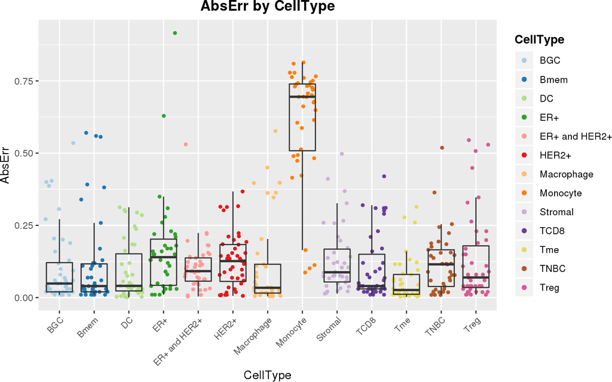

```r
distErrorPlot(
  DDLSChungSmall,
  error = "AbsErr",
  x.by = "CellType",
  color.by = "CellType",
  error.labels = FALSE,
  type = "boxplot",
  size.point = 1
)
```

Now, if you want to know if there are some bias in direction to a specific cell type in determined proportions, you can use the next code:

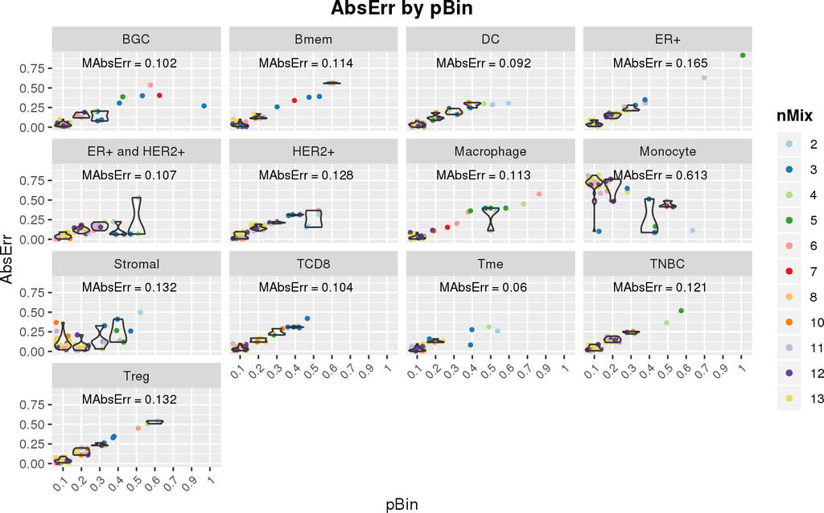

```r
distErrorPlot(
  DDLSChungSmall,
  error = "AbsErr",
  facet.by = "CellType",
  color.by = "nMix",
  error.labels = TRUE,
  type = "violinplot",
  size.point = 1
)
```

It is also possible to represent errors by number of different cell types present in samples:

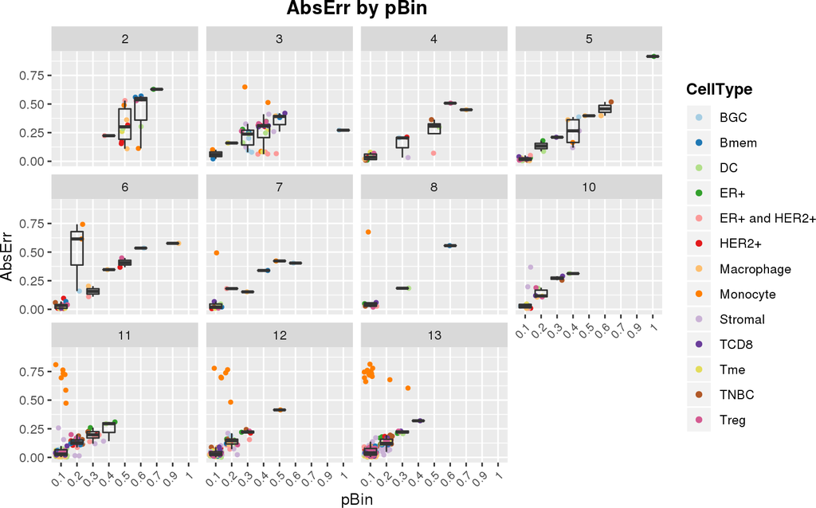

```r
distErrorPlot(
  DDLSChungSmall,
  error = "AbsErr",
  color.by = "CellType",
  facet.by = "nMix",
  type = "boxplot",
  size.point = 1
)
```

Finally, with `barErrorPlot` you can represent the mean error values with their corresponding dispersion ranges as follows:

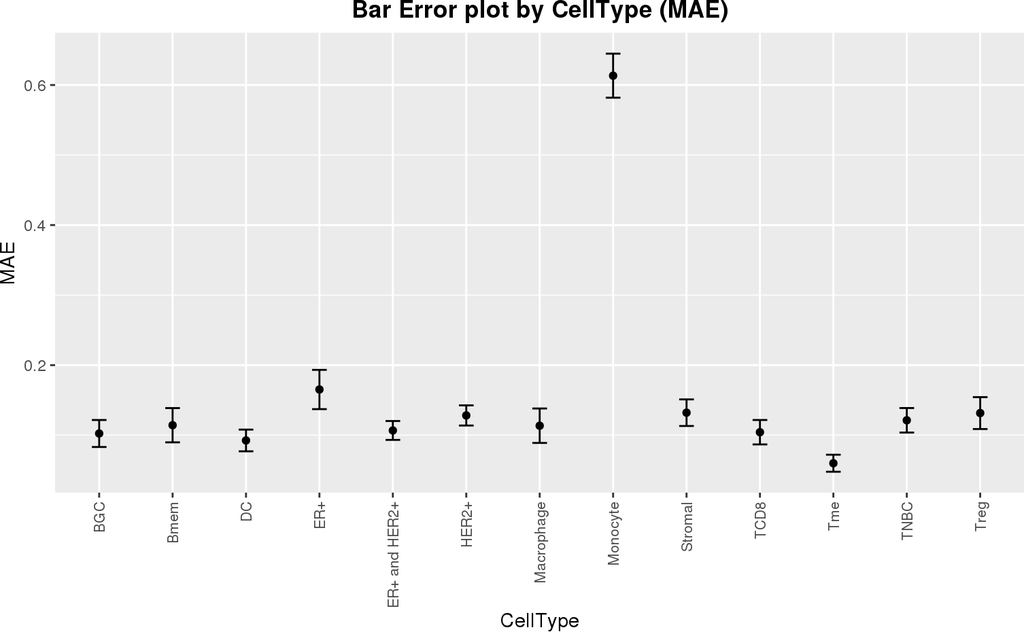

```r
barErrorPlot(DDLSChungSmall, error = "MAE", by = "CellType")
```

### 4.8.2 Correlation plots between predicted and expected proportions

Ideally, the model should provide predictions that fit linearly to the real proportions. Thus, you can generate correlations plots in order to evaluate how well the predictions fit the actual proportions. By default, Pearson’s coefficient correlation ($R$) and concordance correlation coefficient (CCC) are shown as annotations in plots. The latter is a more realistic measure of the situation, as it decreases as the points move away from the perfect diagonal.

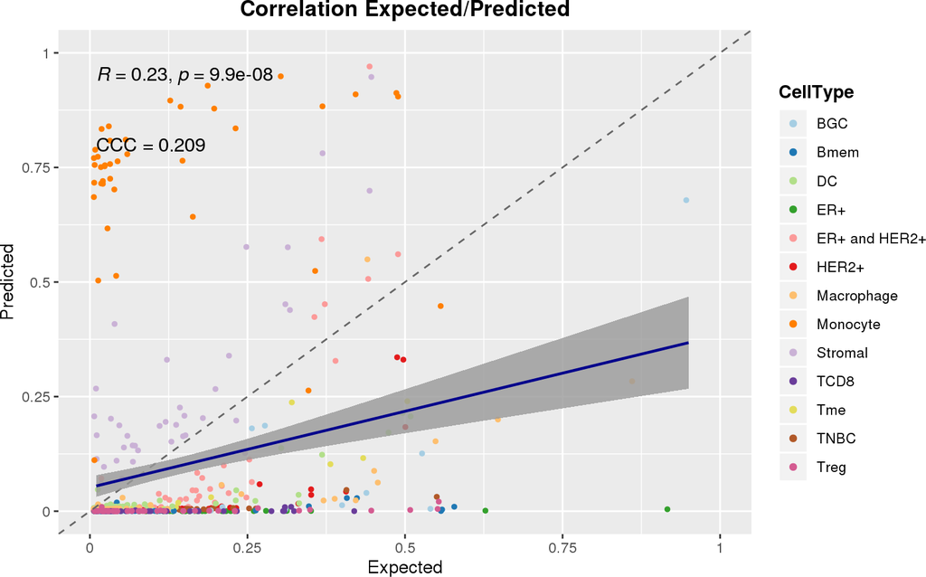

```r
corrExpPredPlot(
  DDLSChungSmall,
  color.by = "CellType",
  size.point = 1,
  corr = "both"
)
```

As in the previous case, charts can be divided according to different variables. Now, we are going to split results by `CellType` and by `nMix`:

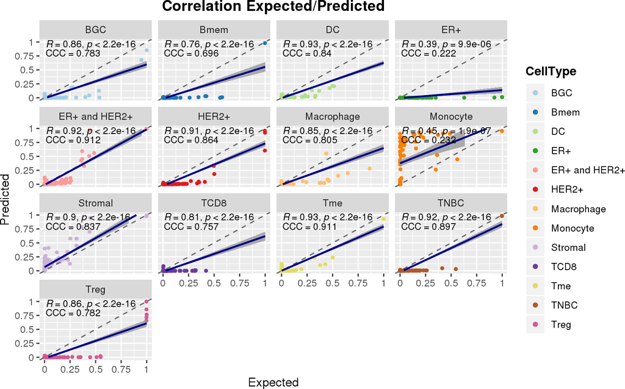

```r
corrExpPredPlot(
  DDLSChungSmall,
  color.by = "CellType",
  facet.by = "CellType",
  size.point = 1,
  filter.sc = F,
  corr = "both"
)
## Warning: Removed 530 rows containing missing values (geom_point).
## Warning: Removed 41 rows containing missing values (geom_smooth).
```

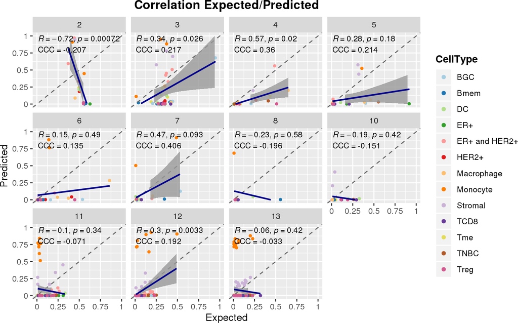

```r
corrExpPredPlot(
  DDLSChungSmall,
  color.by = "CellType",
  facet.by = "nMix",
  size.point = 1,
  corr = "both"
)
## Warning: Removed 50 rows containing missing values (geom_smooth).
```

### 4.8.3 Bland-Altman agreement plots

`blandAltmanLehPlot` allows to display the Bland-Altman agreement plot. This is a graphic method to compare the agreement between two different set of values. The differences between predictions and real proportions are plotted against the averages of the two values. The central dashed line represents the mean different, while the two red dashed lines are the limits of agreement, which are defined as the mean difference plus and minus 1.96 times the standard deviation of the differences. 95% of the differences are expected to fall between these two limits. It is also possible the representation in $log_2$ space.

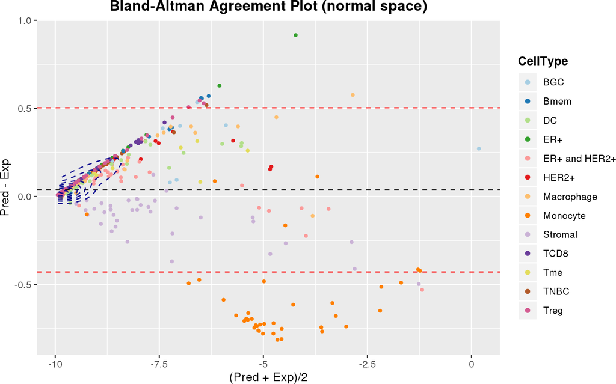

```r
blandAltmanLehPlot(
  DDLSChungSmall,
  color.by = "CellType",
  log.2 = FALSE,
  size.point = 1,
  filter.sc = TRUE,
  density = TRUE,
)
```

Moreover, this function has the same behavior as the previous ones:

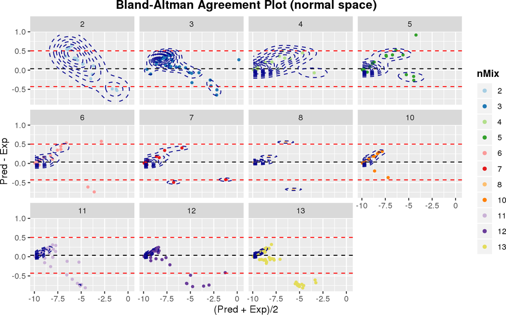

```r
blandAltmanLehPlot(
  DDLSChungSmall,
  color.by = "nMix",
  facet.by = "nMix",
  log.2 = FALSE,
  size.point = 1,
  filter.sc = TRUE,
  density = TRUE,
)
```